# Assignment 9

Caitlyn Gramajo

2024-03-24

## Assignment 9

## Goal

I will create a logistic regression model to predict whether or not a student will be admitted to Graduate School using the “GradSchool_Admissions.csv” data set

## Libaray

For the set up I used 6 libraries:

tidyverse

caret

easystats

modelr

MASS

GGally

## Data

```
## Rows: 400
## Columns: 4
## $ admit <dbl> 0, 1, 1, 1, 0, 1, 1, 0, 1, 0, 0, 0, 1, 0, 1, 0, 0, 0, 0, 1, 0, 1…
## $ gre   <dbl> 380, 660, 800, 640, 520, 760, 560, 400, 540, 700, 800, 440, 760,…
## $ gpa   <dbl> 3.61, 3.67, 4.00, 3.19, 2.93, 3.00, 2.98, 3.08, 3.39, 3.92, 4.00…
## $ rank  <dbl> 3, 3, 1, 4, 4, 2, 1, 2, 3, 2, 4, 1, 1, 2, 1, 3, 4, 3, 2, 1, 3, 2…
```

```
## [1] "admit" "gre"   "gpa"   "rank"
```

The Data set has 4 columns: 2 continues (GRE score and GPA), 1 logical (admit 1 is yes 0 is no), and 1 rank (1,2,3,4) with 1 meaning that the school is “top tier”.

## Plots

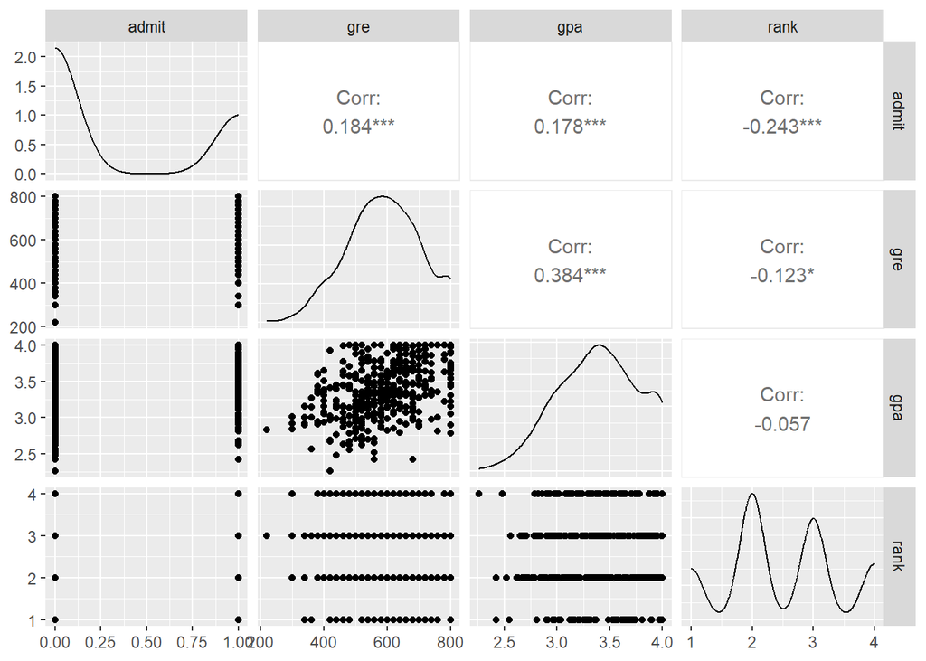

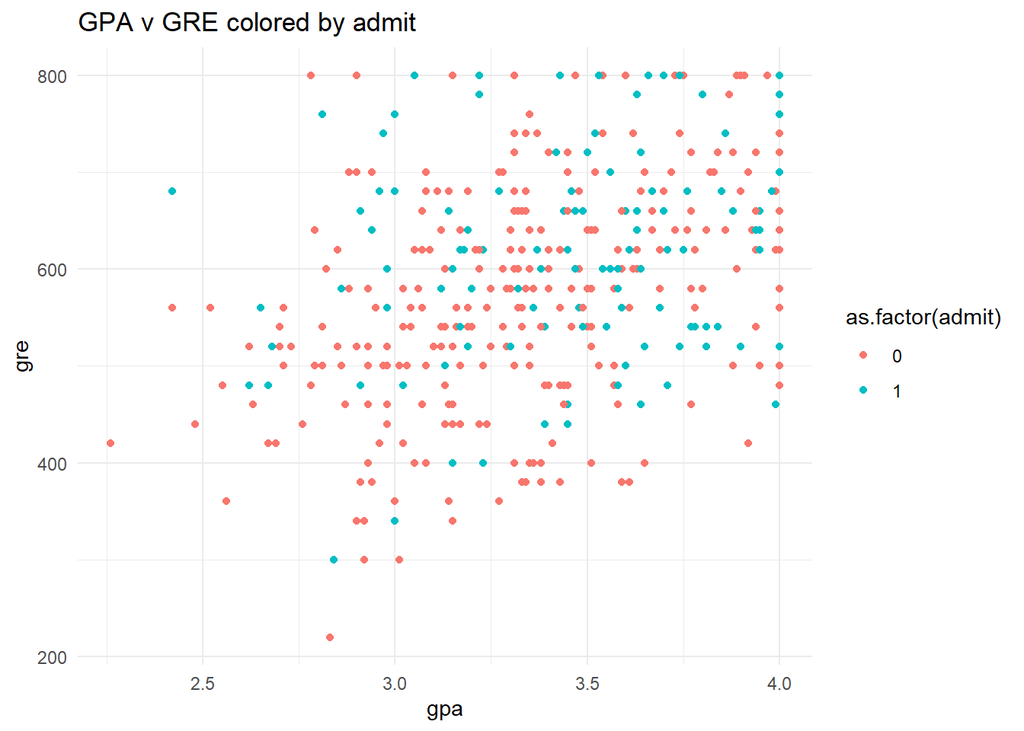

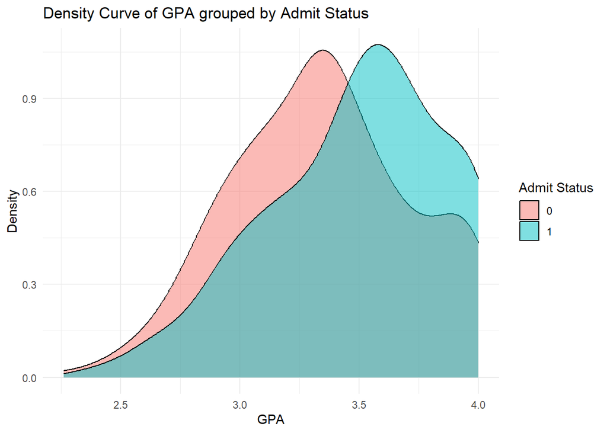

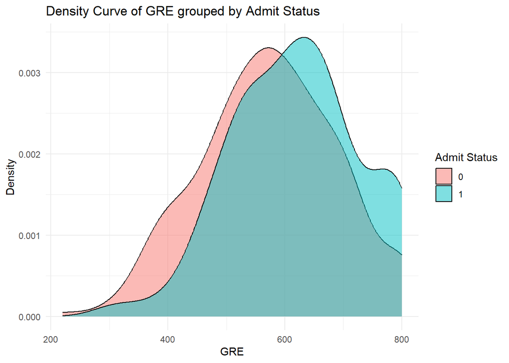

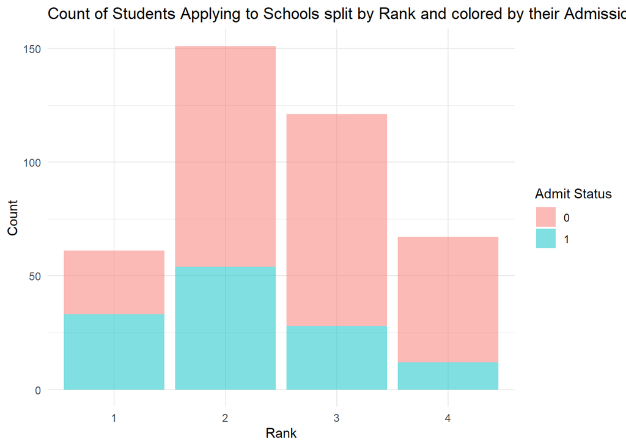

## Analysis from the Plots

We can see from GPA v GRE colored by admit that there is more rejections than acceptations and that the acceptations are more spread out than the rejections. I wonder if the acceptance points that are lower correlate to lower rank schools. From the Density Curve of GPA grouped by Admit Status can see that the mean GPA of students who were admitted is higher than that of the GPA of students where rejected but the two curves are very similar. From the Density Curve of GRE grouped by Admit Status we can see that the mean gre of students who were admitted is a little higher than that of the gre of students where rejected however the two density curves overlap so much that I am suspicious that gre does not matter as much as gpa does. From the bar chart or the ranks of the schools colored by admit status we can see that all but rank 1 schools reject more than the accept I wonder if lower rank schools get more applicants.

## Splitting the data

For testing any models I make I am going to use a subset of the data that the model was not trained on and have it predict the probability of the student being admitted. These data sets are train for the training data and test for the testing data.

## Making some modles

Model 1 (mod1) uses the students GRE score, GPA and the rank the school to predict if the student will be accepted.

Model 2 (mod2) uses the students GPA and the rank the school to predict if the student will be accepted.

Model 3 (mod3) uses the students GRE score and the rank the school to predict if the student will be accepted.

Model 4 (mod4) uses the students GRE score and GPA to predict if the student will be accepted.

Model 5 (mod5) uses the rank the school to predict if the student will be accepted.

Model 6 (mod6) uses the students GRE score, GPA, the rank the school and all interaction terms to predict if the student will be accepted.

```
##
## Call:
## glm(formula = as.logical(admit) ~ gre + gpa + factor(rank), family = binomial,
##     data = train)
##
## Coefficients:
##                Estimate Std. Error z value Pr(>|z|)
## (Intercept)   -3.909385   1.298110  -3.012 0.002599 **
## gre            0.002577   0.001276   2.019 0.043497 *
## gpa            0.729321   0.386301   1.888 0.059031 .
## factor(rank)2 -0.823428   0.357275  -2.305 0.021181 *
## factor(rank)3 -1.404006   0.386809  -3.630 0.000284 ***
## factor(rank)4 -1.646655   0.474627  -3.469 0.000522 ***
## ---
## Signif. codes:  0 '***' 0.001 '**' 0.01 '*' 0.05 '.' 0.1 ' ' 1
##
## (Dispersion parameter for binomial family taken to be 1)
##
##     Null deviance: 392.63  on 319  degrees of freedom
## Residual deviance: 357.50  on 314  degrees of freedom
## AIC: 369.5
##
## Number of Fisher Scoring iterations: 4
```

```
##
## Call:
## glm(formula = as.logical(admit) ~ gpa + factor(rank), family = binomial,
##     data = train)
##
## Coefficients:
##               Estimate Std. Error z value Pr(>|z|)
## (Intercept)    -3.4052     1.2607  -2.701 0.006912 **
## gpa             1.0429     0.3548   2.939 0.003291 **
## factor(rank)2  -0.8569     0.3539  -2.422 0.015454 *
## factor(rank)3  -1.4722     0.3823  -3.851 0.000118 ***
## factor(rank)4  -1.6869     0.4712  -3.580 0.000344 ***
## ---
## Signif. codes:  0 '***' 0.001 '**' 0.01 '*' 0.05 '.' 0.1 ' ' 1
##
## (Dispersion parameter for binomial family taken to be 1)
##
##     Null deviance: 392.63  on 319  degrees of freedom
## Residual deviance: 361.67  on 315  degrees of freedom
## AIC: 371.67
##
## Number of Fisher Scoring iterations: 4
```

```
##
## Call:
## glm(formula = as.logical(admit) ~ gre + factor(rank), family = binomial,
##     data = train)
##
## Coefficients:
##                Estimate Std. Error z value Pr(>|z|)
## (Intercept)   -1.979517   0.777568  -2.546 0.010903 *
## gre            0.003544   0.001173   3.021 0.002515 **
## factor(rank)2 -0.847403   0.354275  -2.392 0.016760 *
## factor(rank)3 -1.364319   0.382414  -3.568 0.000360 ***
## factor(rank)4 -1.718269   0.471576  -3.644 0.000269 ***
## ---
## Signif. codes:  0 '***' 0.001 '**' 0.01 '*' 0.05 '.' 0.1 ' ' 1
##
## (Dispersion parameter for binomial family taken to be 1)
##
##     Null deviance: 392.63  on 319  degrees of freedom
## Residual deviance: 361.13  on 315  degrees of freedom
## AIC: 371.13
##
## Number of Fisher Scoring iterations: 4
```

```
##
## Call:
## glm(formula = as.logical(admit) ~ gpa + gre, family = binomial,
##     data = train)
##
## Coefficients:
##              Estimate Std. Error z value Pr(>|z|)
## (Intercept) -5.139744   1.223157  -4.202 2.65e-05 ***
## gpa          0.737655   0.369834   1.995   0.0461 *
## gre          0.002972   0.001228   2.420   0.0155 *
## ---
## Signif. codes:  0 '***' 0.001 '**' 0.01 '*' 0.05 '.' 0.1 ' ' 1
##
## (Dispersion parameter for binomial family taken to be 1)
##
##     Null deviance: 392.63  on 319  degrees of freedom
## Residual deviance: 375.77  on 317  degrees of freedom
## AIC: 381.77
##
## Number of Fisher Scoring iterations: 4
```

```
##
## Call:
## glm(formula = as.logical(admit) ~ as.factor(rank), family = binomial,
##     data = train)
##
## Coefficients:
##                  Estimate Std. Error z value Pr(>|z|)
## (Intercept)        0.2048     0.2872   0.713 0.475822
## as.factor(rank)2  -0.9107     0.3475  -2.620 0.008786 **
## as.factor(rank)3  -1.4576     0.3754  -3.883 0.000103 ***
## as.factor(rank)4  -1.8142     0.4646  -3.905 9.42e-05 ***
## ---
## Signif. codes:  0 '***' 0.001 '**' 0.01 '*' 0.05 '.' 0.1 ' ' 1
##
## (Dispersion parameter for binomial family taken to be 1)
##
##     Null deviance: 392.63  on 319  degrees of freedom
## Residual deviance: 370.71  on 316  degrees of freedom
## AIC: 378.71
##
## Number of Fisher Scoring iterations: 4
```

```
##
## Call:
## glm(formula = step$formula, family = binomial, data = train)
##
## Coefficients:
##                   Estimate Std. Error z value Pr(>|z|)
## (Intercept)      -3.909385   1.298110  -3.012 0.002599 **
## gpa               0.729321   0.386301   1.888 0.059031 .
## gre               0.002577   0.001276   2.019 0.043497 *
## as.factor(rank)2 -0.823428   0.357275  -2.305 0.021181 *
## as.factor(rank)3 -1.404006   0.386809  -3.630 0.000284 ***
## as.factor(rank)4 -1.646655   0.474627  -3.469 0.000522 ***
## ---
## Signif. codes:  0 '***' 0.001 '**' 0.01 '*' 0.05 '.' 0.1 ' ' 1
##
## (Dispersion parameter for binomial family taken to be 1)
##
##     Null deviance: 392.63  on 319  degrees of freedom
## Residual deviance: 357.50  on 314  degrees of freedom
## AIC: 369.5
##
## Number of Fisher Scoring iterations: 4
```

## Comparing the Models

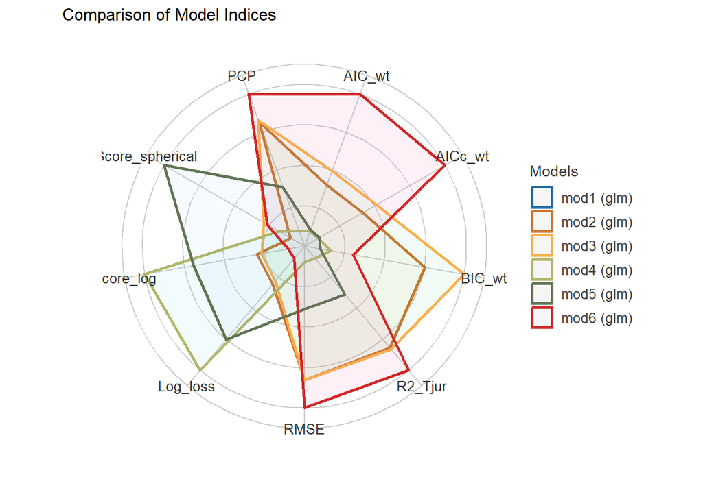

```
## # Comparison of Model Performance Indices
##
## Name | Model | AIC (weights) | AICc (weights) | BIC (weights) | Tjur's R2 |  RMSE | Sigma | Log_loss | Score_log | Score_spherical |   PCP
## ------------------------------------------------------------------------------------------------------------------------------------------
## mod1 |   glm | 369.5 (0.358) |  369.8 (0.354) | 392.1 (0.122) |     0.109 | 0.434 | 1.000 |    0.559 |   -36.686 |           0.005 | 0.624
## mod2 |   glm | 371.7 (0.121) |  371.9 (0.125) | 390.5 (0.272) |     0.098 | 0.436 | 1.000 |    0.565 |   -36.323 |           0.004 | 0.619
## mod3 |   glm | 371.1 (0.158) |  371.3 (0.163) | 390.0 (0.355) |     0.098 | 0.436 | 1.000 |    0.564 |   -36.377 |           0.006 | 0.619
## mod4 |   glm | 381.8 (<.001) |  381.8 (<.001) | 393.1 (0.075) |     0.052 | 0.448 | 1.000 |    0.587 |   -35.015 |           0.005 | 0.599
## mod5 |   glm | 378.7 (0.004) |  378.8 (0.004) | 393.8 (0.053) |     0.070 | 0.443 | 1.000 |    0.579 |   -35.585 |           0.012 | 0.607
## mod6 |   glm | 369.5 (0.358) |  369.8 (0.354) | 392.1 (0.122) |     0.109 | 0.434 | 1.000 |    0.559 |   -36.686 |           0.005 | 0.624
```

No model is the best in all categories but I choose Model 1 which is the same as Model 6 (which means that none of the interaction terms were significant interesting enough) because it has the lowest AIC and AICc dispite being the most complex. All models have the same Sigma but model 1 gets more predictions correct than the other models and has the lowest RMSE of the. It also explains the most this is shown by the the R2 value.

## Checking Model 1

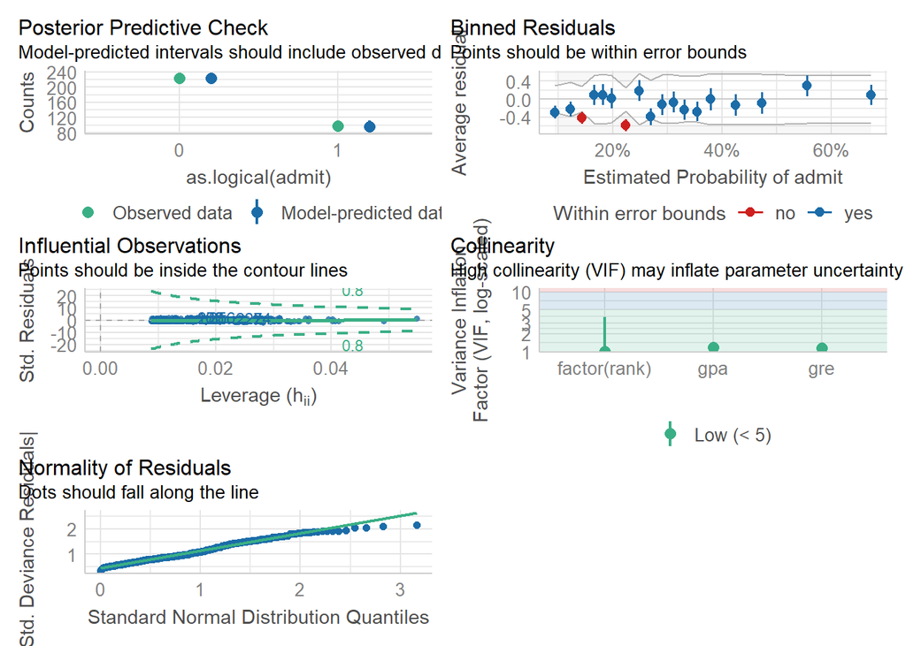

Looking at the residuals we can see that they are normally distributed very strongly up until about 2 but even then they are not too far away. We can see in the influential observations plot that are no observations with high leverage meaning that no one observation has more leverage than the others. We can also see that all of the predictors are within the green zone for colinearity meaning they are not influencing each other too much. This is good because our predictors must be independent.

## Using Model 1 to predict with the test data set

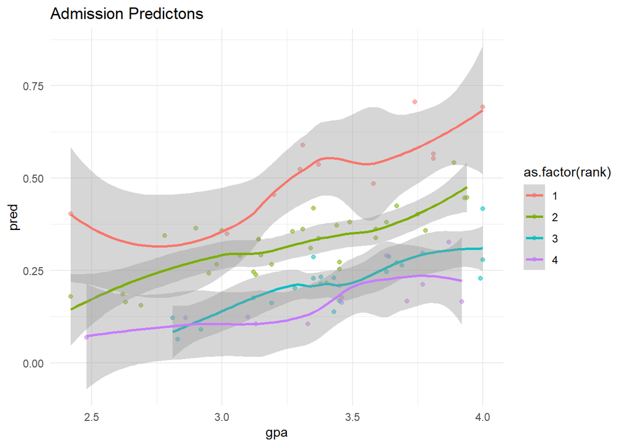

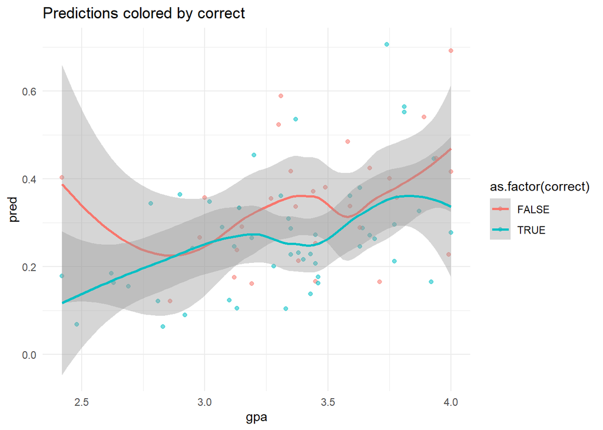

After using the test data set and plotting them we see that rank 1 school have the most variation in their predictions. Investigating into how many of these ne predictions are correct with a prediction value of 0.5 or higher being acceptions and less than 0.5 being rejection we find that 0.625 of the predictions are correct. Plotting the predictions colored by whether they were correct or not shows that more of them are correct.